# The Normal Test

2025

## Introduction

- Suppose we are interested in understanding receptive field properties of a particular neuron.
- We know from past research that – in the absence of all external inputs – this neuron has a baseline firing rate of 10 spikes per second on average.
- However, the baseline firing rate is not constant, but fluctuates around this average value.

## Baseline firing in a cool neuron

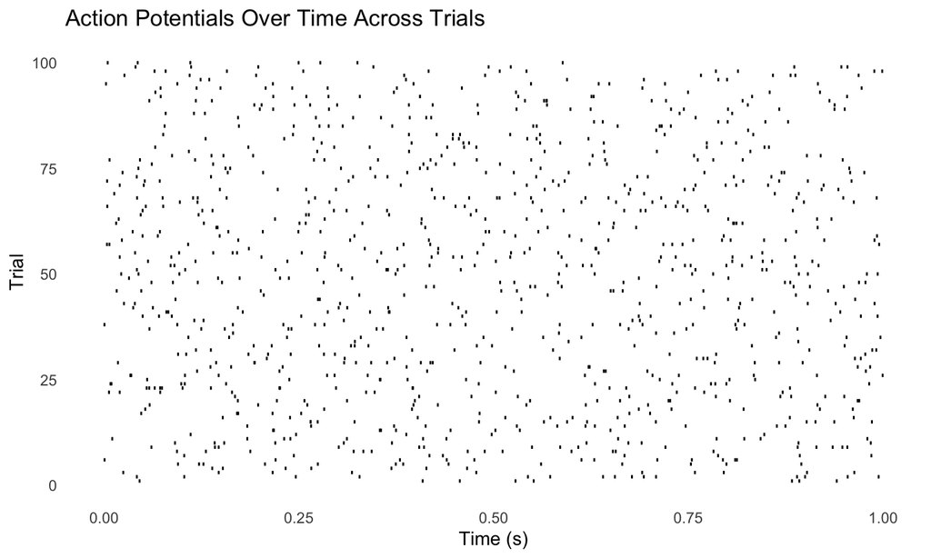

## Cool stimulus-driven firing

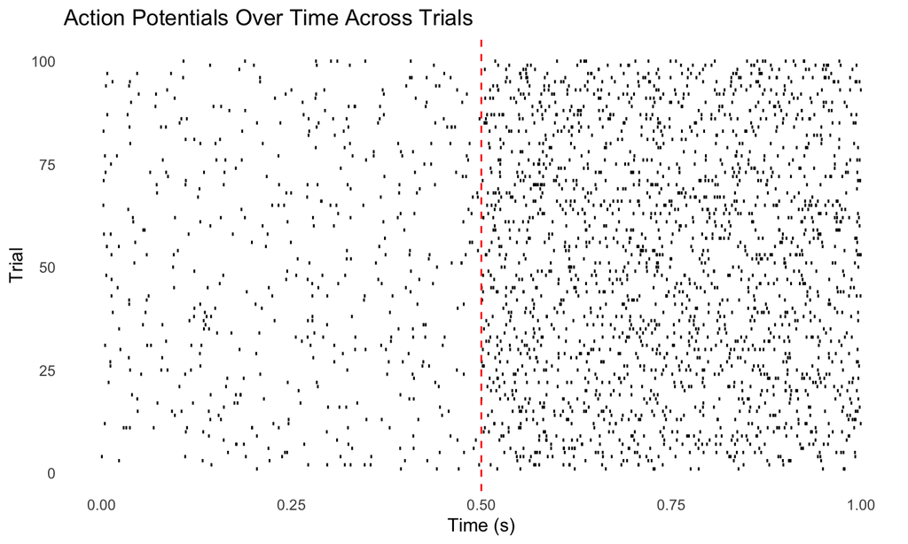

## Still cool?

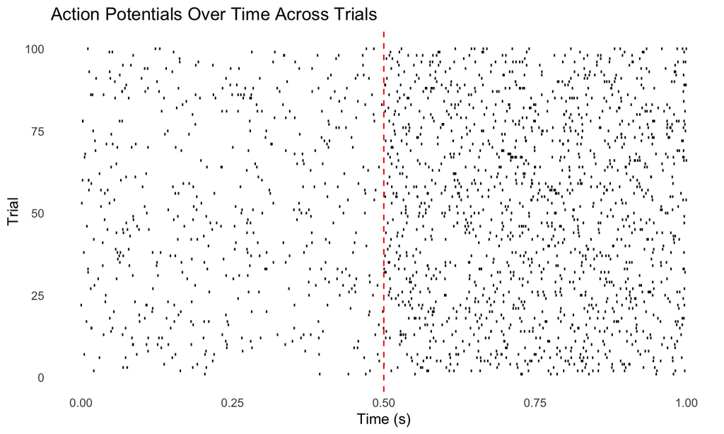

## How about now?

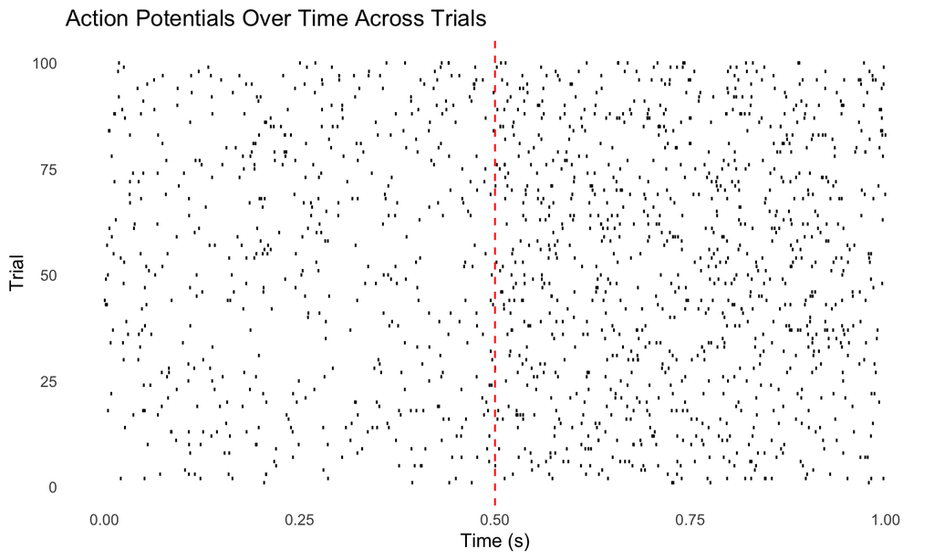

## And now?

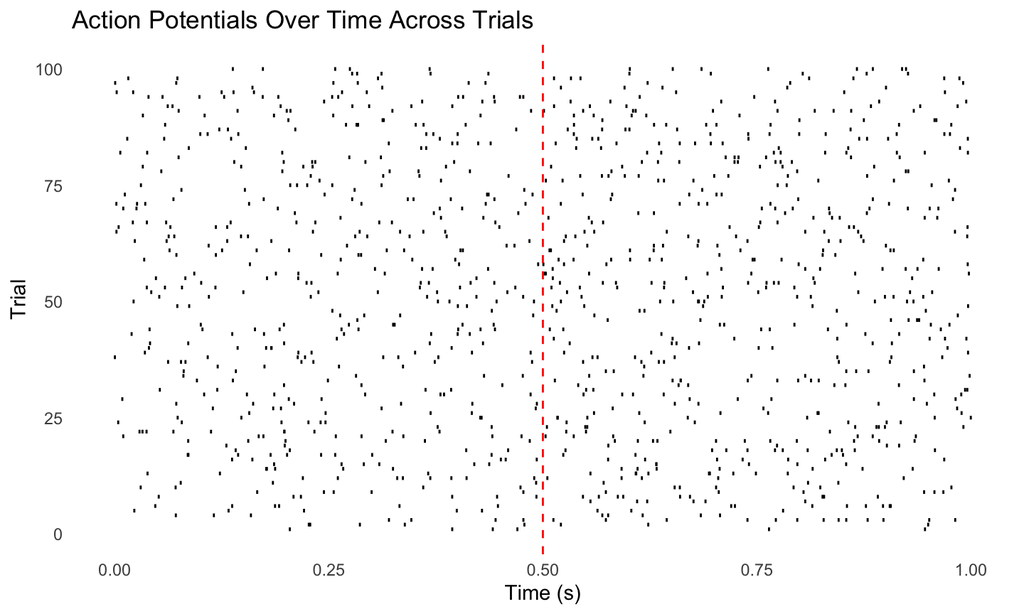

## We need a formal method

- Suppose we know the **Expected Value** of the baseline firing rate of this neuron is 10 spikes per second.
- Let \(X\) to be the random variable that generates the observed number of spikes per second during the stimulus.
- We want to know if the neuron is stimulus-driven.
- That is, we want to know if the **Expected Value** of \(X\) is greater than 10 spikes per second.
- \(\mathbb{E}(X) > 10\)???
- \(\mu_X > 10\)???

## Imagine two universes

- **Null Universe**: The neuron is not stimulus-driven. The **Expected Value** of \(X\) is 10 spikes per second.
- **Alternative Universe**: The neuron is stimulus-driven.
- We want to know which universe we are in.
- We write this as:

\[ \begin{align*} H_0 &: \mu_X = 10 \\ H_1 &: \mu_X > 10 \end{align*} \]

## Start by building a model of the Null

- The Null (\(H_0\)) universe is the universe where the neuron is not stimulus-driven.
- The **Expected Value** of \(X_{H0}\) is 10 spikes per second.
- Assume that the distribution of \(X_{H0}\) is Normal with mean 10 and standard deviation \(\sigma_X = 1\).

## The Null Universe

- \(X \sim \mathscr{N}(\mu_X=10, \sigma_X=1)\)

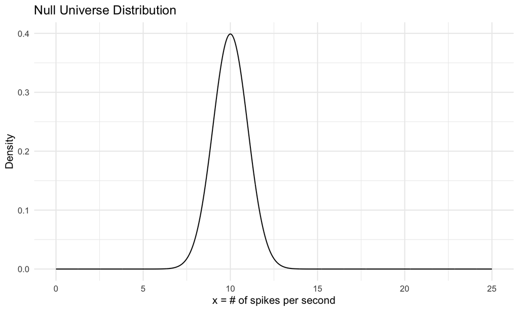

## Is this a good model?

- Firing rate - i.e., \(X_{H0}\) – is continuous and can take any value between 0 and \(\infty\).
- \(X \sim \mathscr{N}(\mu_X=10, \sigma_X=1)\) is continuous but is defined for \((-\infty, \infty)\).
- firing rate cannot be negative but our model can be negative. This is a weakness of the model.
- However, \(X \sim \mathscr{N}(\mu_X=10, \sigma_X=1)\) assigns very near zero probability to negative values, so this model may not be too bad afterall.

## Sample from \(X \rightarrow\) compare to Null

- Stimulate 25 times and observe the spikes per second in each case.

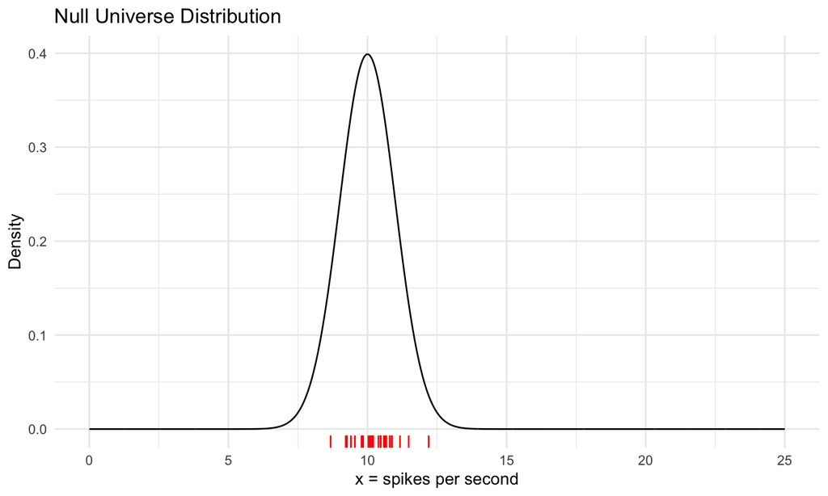

## We had to wrangle the data

- Remember that our experiment generates the spike time raster plots from the beginning of this slide deck.
- We had to wrangle the data to get the number of spikes per second from those plots.
- This is where your `data.table` skills would come in handy.

## Our raw data isn’t a good fit for our question

- Recall that our question is expressed as follows:

\[ \begin{align*} H_0 &: \mu_X = 10 \\ H_1 &: \mu_X > 10 \end{align*} \]

- Our raw data doesn’t immediately and unambiguously tell us about \(\mu_X\).

## We need an estimate of \(\mu_X\)

- We can estimate \(\mu_X\) by taking the sample mean of the observed firing rates.
- We denote *estimate of \(\mu_X\)* as \(\widehat{\mu_X}\).
- \(\widehat{\mu_X} = \bar{x}\)
- \(\bar{x} = \frac{1}{n} \sum_{i=1}^{n} x_i\)

## The sample mean: visual

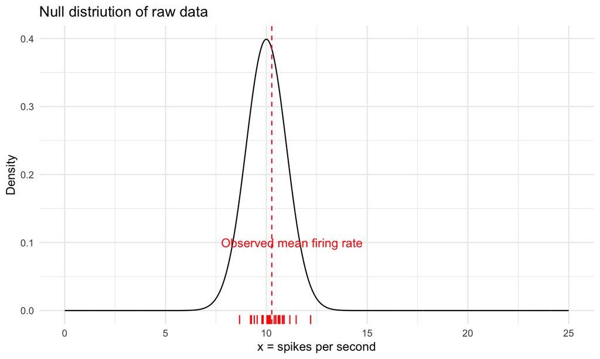

## How likely is \(\bar{x}\) under the Null?

- This is the same as asking: \(P(\bar{X}_{H0} > \bar{x}_{obs})\)
- How can we compute this probability?
- We know that we need area under the curve of the probability distribution given a continuous distribution.
- This may give us the idea on the next slide…

## It may be very tempting to do this

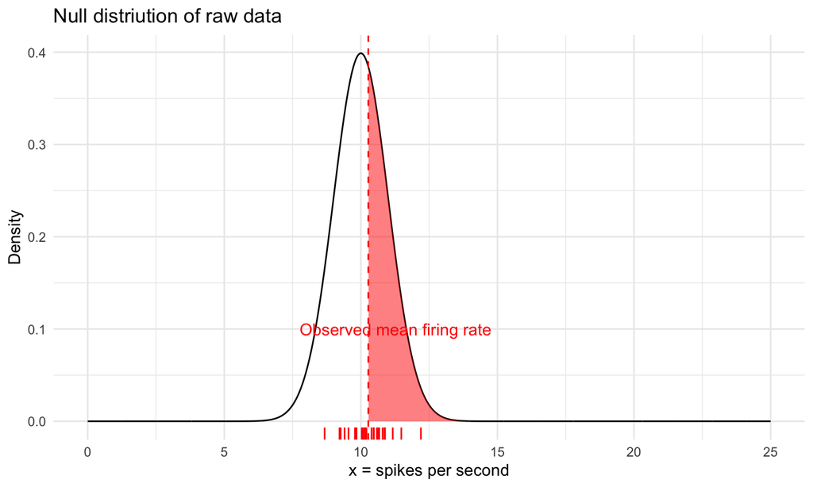

## What’s wrong with this approach?

- Can you see what’s wrong with this approach?
- Suspense…

## It’s the wrong probability distribution

- The random variable that generates the raw data (\(X\)) is different from the random variable that generates the sample mean (\(\bar{X}\)).
- Since we are asking about how likely an observed sample mean is under the Null, we should be using the distribution of the sample mean.

## Raw data vs sample mean

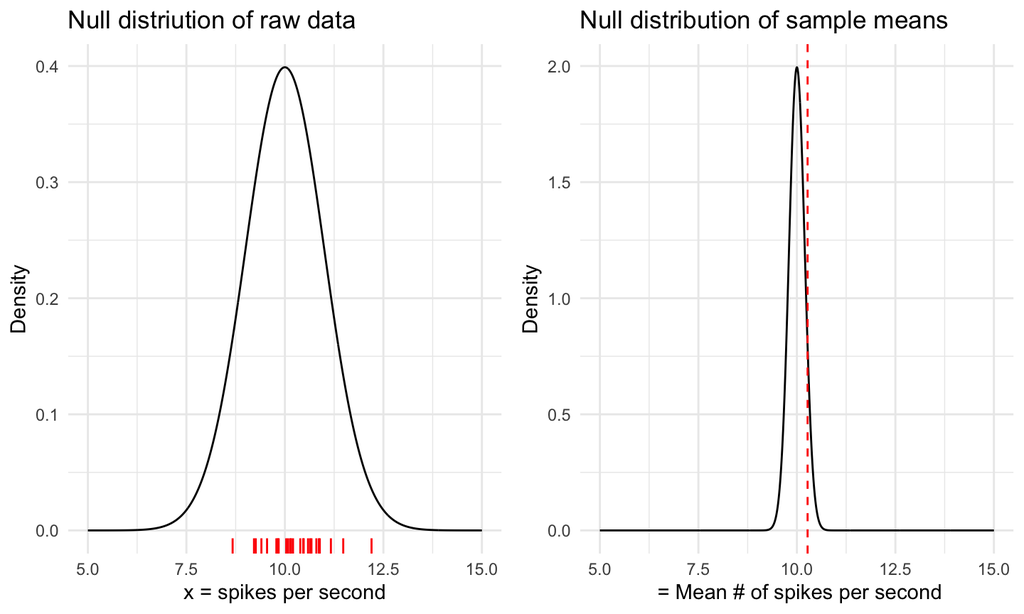

## How likely is the Null Universe?

- The shaded area gives us \(P(\bar{X}_{H0} > \bar{x}_{obs})\)
- This is called the **p-value**.

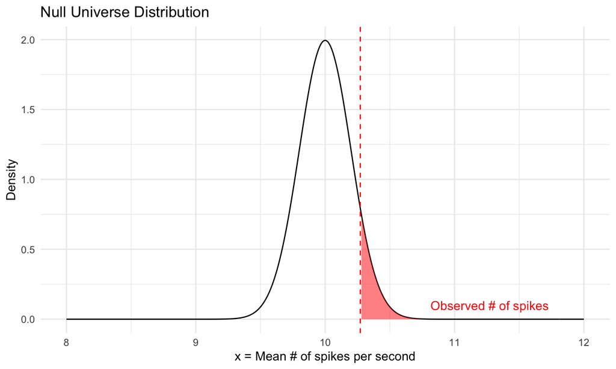

## Why do we include all the probability to the right?

- We are interested in the probability that the Expected Value – i.e., the population mean of the firing rate is **greater** than 10 spikes per second.
- The inequality is baked into the our original question.

## H0 vs H1: Making a decision?

- If the p-value is very small then the Null is very unlikely and we reject it.
- But how small is very small?
- This is choice we have to make and we will discuss it more when we discuss inferential errors and statistical power.
- For now, it’s enough to say that in pychology and neuroscience a p-value of 0.05 is often used.
- This number is called the **Type I error rate** and is denoted by the symbol \(\alpha\).

## Making the decision

- For this example, the p-value turns out to be:

```
## [1] 0.08729804
```

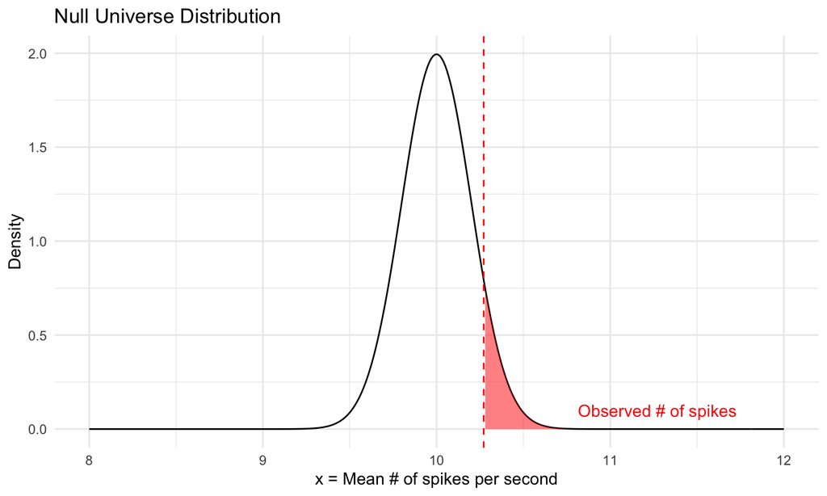

## Summary Recipe

1. Specify the null and alternative hypotheses (\(H_0\) and \(H_1\)) in terms of a population parameter \(\theta\).
2. Specify the type I error rate – denoted by the symbol \(\alpha\) – you are willing to tolerate.
3. Specify the sample statistic \(\widehat{\theta}\) that you will use to estimate the population parameter \(\theta\) in step 1 and state how it is distributed under the assumption that \(H_0\) is true.
4. Obtain a random sample and use it to compute the sample statistic from step 3. Call this value \(\widehat{\theta}_{\text{obs}}\).
5. If \(\widehat{\theta}_{\text{obs}}\) or a **more extreme outcome** is very unlikely to occur under the assumption that \(H_0\) is true, then reject \(H_0\). Otherwise, do not reject \(H_0\).

## Question

Consider the following figure. Can a Normal test be conducted on the basis of the information provided to you in this figure or is something essential missing?

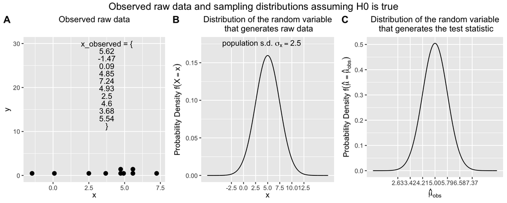

**Answer**

- The observed data can be obtained by reading from panel A. We see that there are 10 observations so \(n=10\)
- Panel B shows that the random variable that generates the raw data is Normal with mean 5 and standard deviation 2.5.
- Panel C shows that the distribution that generates the test statistic is Normal with mean 5, and standard deviation that looks to be about 2.5/sqrt(10).
- Since the distribution of the test statistic is Normal, we can conduct a Normal test.
- So yes, we have everything we need. Hooray!

## Question

Let \(\theta\) be a population parameter of interest and suppose that we know the following about it’s estimator \(\hat{\theta}\):

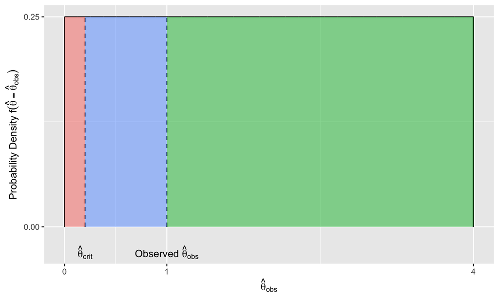

- What is the expected value of \(\hat{\theta}\)?
- What is the observed value of the test statistic?
- What is the \(p\)-value of this test?
- What is the critical value of this test (i.e., the value that ensures that type I error is less than or equal to \(0.05\))?